# Positive feedback measures

Marc

10 April 2016

## Positive feedback model

The purpose of this document is to present and explore different measures of positive feedback. For this, we consider a model governed by the following three reactions:

$$\emptyset \underset{k_2}{\stackrel{k_1}{\rightleftharpoons}} A \underset{k_3}{\longrightarrow} A + A$$

where $k_1$ is the birth rate, $k_2$ is the decay rate and $k_3$ is the positive feedback strength. We want to study stochastic realisations of this model using the stochastic simulation algorithm which is implemented in the function “simple_positive_feedback.r”, so first we must source the function.

```r
source('simple_positive_feedback.r')
```

Let’s define parameters, run 100 trajectories of the model and obtain the output:

```r
k_1 = 1
k_2 = 0.1;
k_3 = 0.001;
maxtime = 1000;
timestep = 0.1;
numberofrealisations = 100;
output = simple_positive_feedback(k_1,k_2,k_3,maxtime,timestep,numberofrealisations,0);
```

We can also make a heatmap plot (you may have to install the “fields” package for this – install.packages(“fields”)):

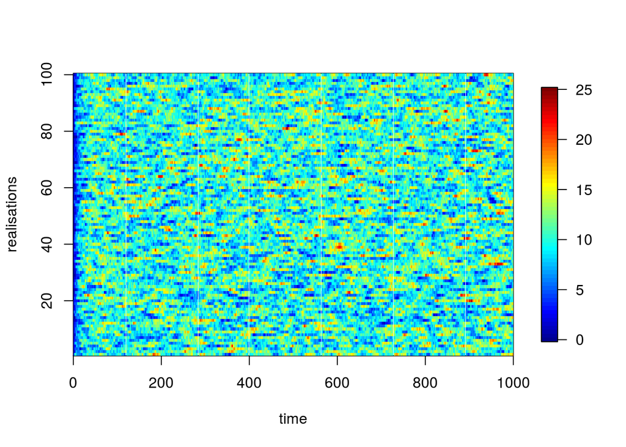

```r
time = seq(0,maxtime,by=timestep);
realisations = 1:numberofrealisations;
image.plot(time,realisations,output);
```

Now that we have a stochastic model with positive feedback strength as a parameter, we can try to find measures that are suitable for identifying positive feedbacks.

## Mean

The first and most obvious measure is the mean. The mean value of $A$ should increase with the positive feedback strength, $k_3$. To study this, first we can plot the mean time series for a single value of $k_3$:

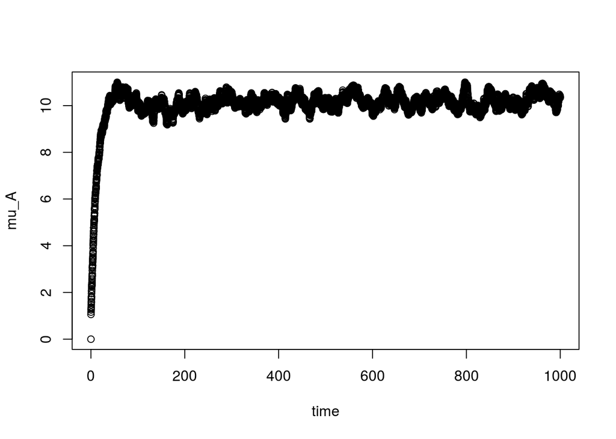

```r
time = seq(0,maxtime,by=timestep);
mu_A = rowMeans(output);
plot(time,mu_A);
```

Since the value of $k_3$ is small, the mean value ($\mu$) of $A$ takes a value just above the steady state with no positive feedback ($\frac{k_1}{k_2}$). We can now look at how the final value of this time series varies with $k_3$.

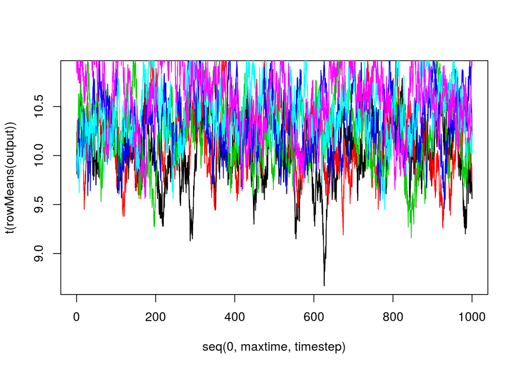

```r
count = 0;
mu_A <- rep(0, 6);
for (k_3 in seq(0,0.005,by=0.001)){
  count = count + 1;
  output = simple_positive_feedback(k_1,k_2,k_3,maxtime,timestep,numberofrealisations,round(k_1/(k_2-k_3)));
  temp_mean_A = rowMeans(output);
  mu_A[count] = temp_mean_A[length(temp_mean_A)];
  if (count==1){plot(seq(0,maxtime,timestep),t(rowMeans(output)),type='l',col=count)}
{lines(seq(0,maxtime,timestep),t(rowMeans(output)),type='l',col=count)}
  }
```

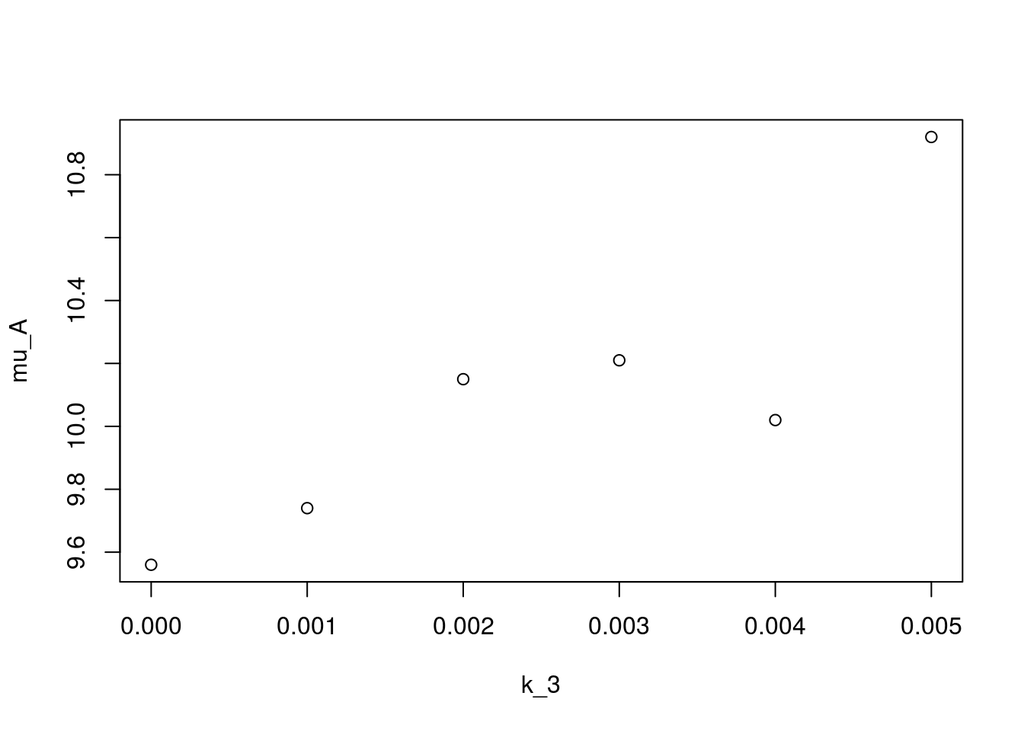

```r
k_3 = seq(0,0.005,by=0.001);
plot(k_3,mu_A);
```

We can see that the mean value increases with positive feedback strength. The next measure we will inspect is the noise of $A$, specifically the Fano Factor.

## Fano Factor

The Fano Factor (F) of $A$ is defined as

$$F =\frac{\sigma^2}{\mu}$$

where $\sigma^2$ is the variance of $A$. To compute this, we need to define the variance, which can be done using the following function:

```r
RowVar <- function(x) {
  rowSums((x - rowMeans(x))^2)/(dim(x)[2] - 1)
}
```

We can now examine the examine the relationship between the positive feedback strength and Fano Factor. Probably need more realisations to get a decent estimate of the Fano Factor.

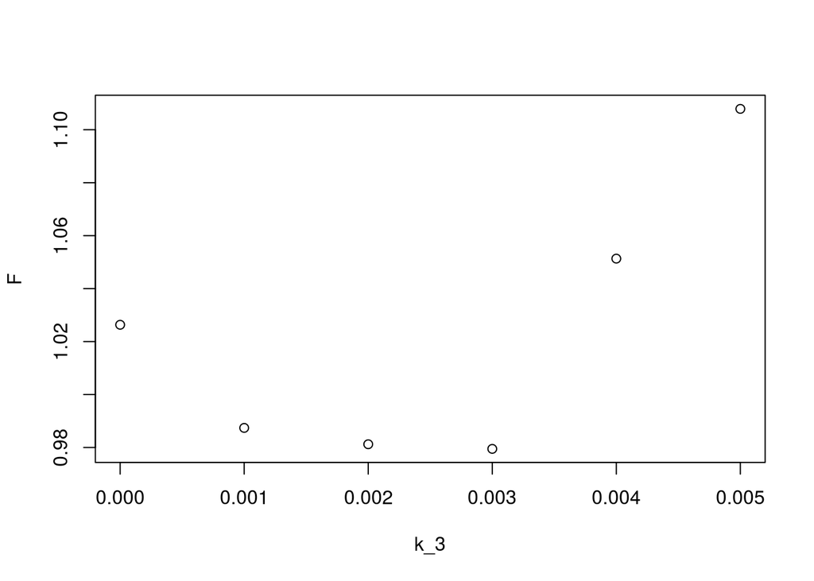

```r
numberofrealisations = 1000;
count = 0;
F <- rep(0, 6);
for (k_3 in seq(0,0.005,by=0.001)){
  count = count + 1;
  output = simple_positive_feedback(k_1,k_2,k_3,maxtime,timestep,numberofrealisations,round(k_1/(k_2-k_3)));
  temp_mean_A = rowMeans(output);
  temp_var_A = RowVar(output);
  F[count] = temp_var_A[length(temp_var_A)]/temp_mean_A[length(temp_mean_A)];
}
k_3 = seq(0,0.005,by=0.001);
plot(k_3,F);
```

## Autocorrelation

For a discrete process with known mean and variance for which we observe n observations $\{X_1,\,X_2,\,\ldots,\,X_n\}$, an estimate of the autocorrelation may be obtained as

$$\hat{R}(k)=\frac{1}{(n-k) \sigma^2} \sum_{t=1}^{n-k} (X_t-\mu)(X_{t+k}-\mu)$$

We can plot an example autocorrelation for a single trajectory of the model and plot it.

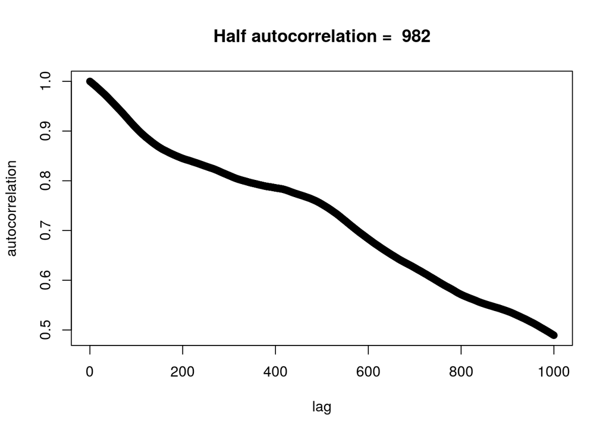

```r
output = simple_positive_feedback(1,0.01,0.001,1000,0.1,1,round(1/(0.01-0.001)));
  autocorr = acf(output,lag.max = 1000,plot = FALSE)
test <- min(abs(autocorr$acf-0.5))
half_autocorr = which(abs(autocorr$acf-0.5) == test)
lag = autocorr$lag;
autocorrelation = autocorr$acf;
plot(lag,autocorrelation,main=paste("Half autocorrelation = ", half_autocorr))
```

Now we can examine how the half autocorrelation (which is displayed in the title of the previous plot) varies with $k_3$.

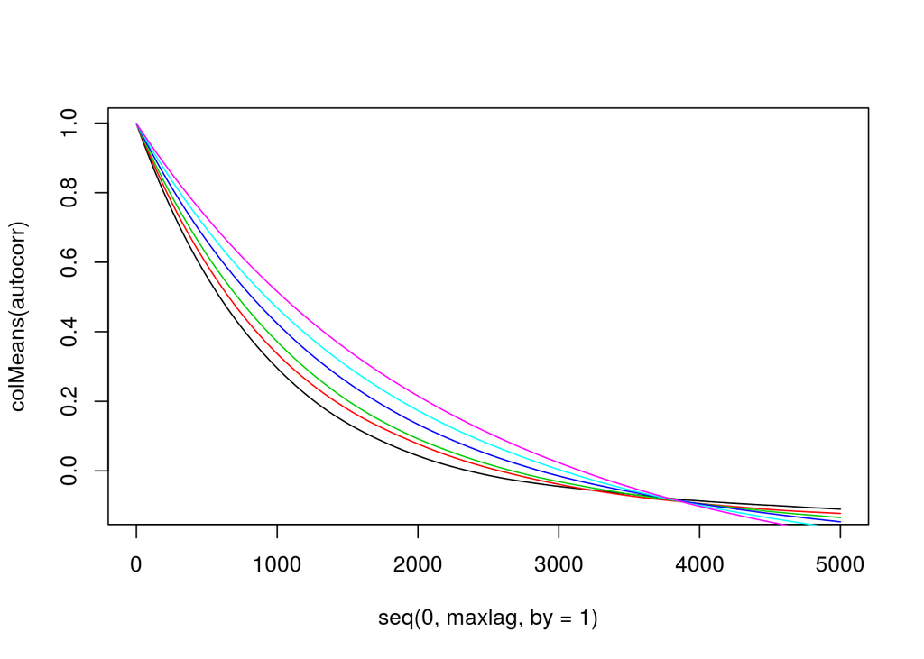

```r
warningnumberofrealisations = 10;
maxlag=5000;
count1 = 0;
half_autocorr <- matrix(0,nrow=6,ncol=numberofrealisations);

for (k_3 in seq(0,0.005,by=0.001)){
  count1 = count1 + 1;
  autocorr <- matrix(0,1,ncol=maxlag+1);
  for (count2 in seq(1,numberofrealisations,by=1)){
  output = simple_positive_feedback(1,0.01,k_3,1000,0.1,1,round(k_1/(k_2-k_3)));
  autocorr1 = acf(output,lag.max = maxlag,plot = FALSE);
  test <- min(abs(autocorr1$acf-0.5))
  autocorr=rbind(autocorr,as.vector(autocorr1$acf))
  half_autocorr[count1,count2] = which(abs(autocorr1$acf-0.5) == test);

  }
  if (count1==1){
  plot(seq(0,maxlag,by=1),colMeans(autocorr),type="l",col=count1)
  }
  else{
lines(seq(0,maxlag,by=1),colMeans(autocorr),type="l",col=count1)
}
#lines(lag,autocorrelation,col="green")
}
```

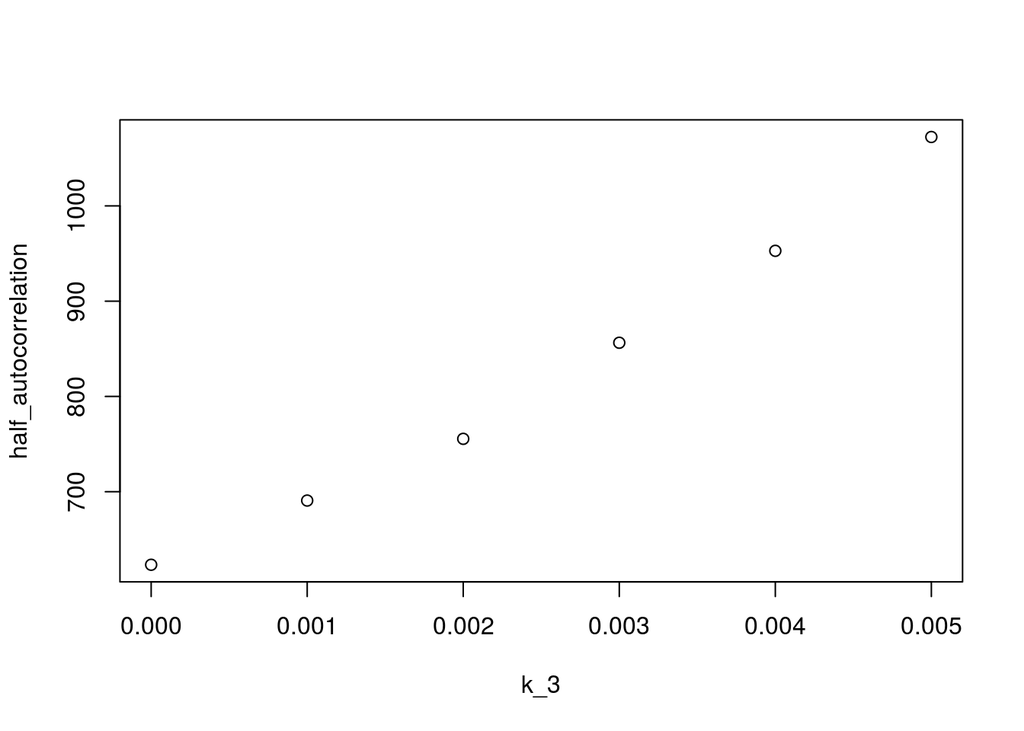

```r
k_3 = seq(0,0.005,by=0.001);
half_autocorrelation = rowMeans(half_autocorr)
plot(k_3,half_autocorrelation);
```

We can compare this with the half autocorrelation of $k_1$ (keeping $k_3 =0$)

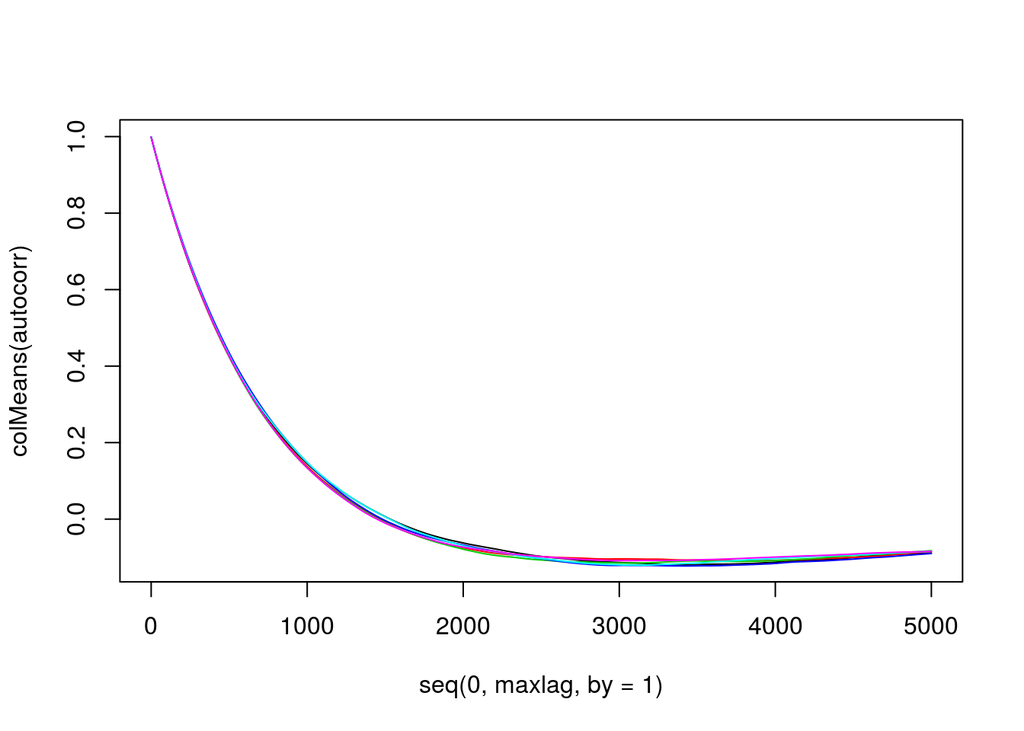

```r
warningnumberofrealisations = 10;
maxlag=5000;
count1 = 0;
half_autocorr <- matrix(0,nrow=6,ncol=numberofrealisations);

for (k_1 in seq(1,6,by=1)){
  count1 = count1 + 1;
  autocorr <- matrix(0,1,ncol=maxlag+1);
  for (count2 in seq(1,numberofrealisations,by=1)){
  output = simple_positive_feedback(k_1,0.01,0,1000,0.1,1,round(k_1/(0.01)));
  autocorr1 = acf(output,lag.max = maxlag,plot = FALSE);
  test <- min(abs(autocorr1$acf-0.5))
  autocorr=rbind(autocorr,as.vector(autocorr1$acf))
  half_autocorr[count1,count2] = which(abs(autocorr1$acf-0.5) == test);

  }
  if (count1==1){
  plot(seq(0,maxlag,by=1),colMeans(autocorr),type="l",col=count1)
  }
  else{
lines(seq(0,maxlag,by=1),colMeans(autocorr),type="l",col=count1)
}
#lines(lag,autocorrelation,col="green")
}
```

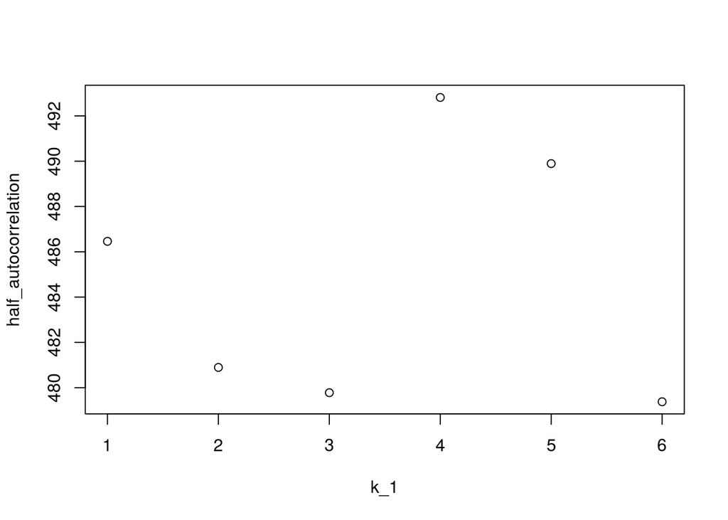

```r
k_1 = seq(1,6,by=1);
half_autocorrelation = rowMeans(half_autocorr)
plot(k_1,half_autocorrelation);
```

## Entropy

Named after Boltzmann’s $H$-theorem, Shannon defined the entropy $H$ (Greek letter $H$) of a discrete random variable X with possible values ${x_1, …, x_n}$ and probability mass function $P(X)$ as:

$$H(X) = \mathrm{E}[\mathrm{I}(X)] = \mathrm{E}[-\ln(\mathrm{P}(X))]$$
.

Here $E$ is the expected value operator, and $I$ is the information content of $X$. $I(X)$ is itself a random variable.

The entropy can explicitly be written as

$$H(X) = \sum_{i=1}^n {\mathrm{P}(x_i)\,\mathrm{I}(x_i)} = -\sum_{i=1}^n {\mathrm{P}(x_i) \log_b \mathrm{P}(x_i)},$$

where $b$ is the base of the logarithm used. Common values of $b$ are $2$, Euler’s number $e$, and $10$, and the unit of entropy is shannon for $b = 2$, nat for $b = e$, and hartley for $b = 10$. When $b = 2$, the units of entropy are also commonly referred to as bits.

We can see how the entropy varies with $k_3$ by doing the following:

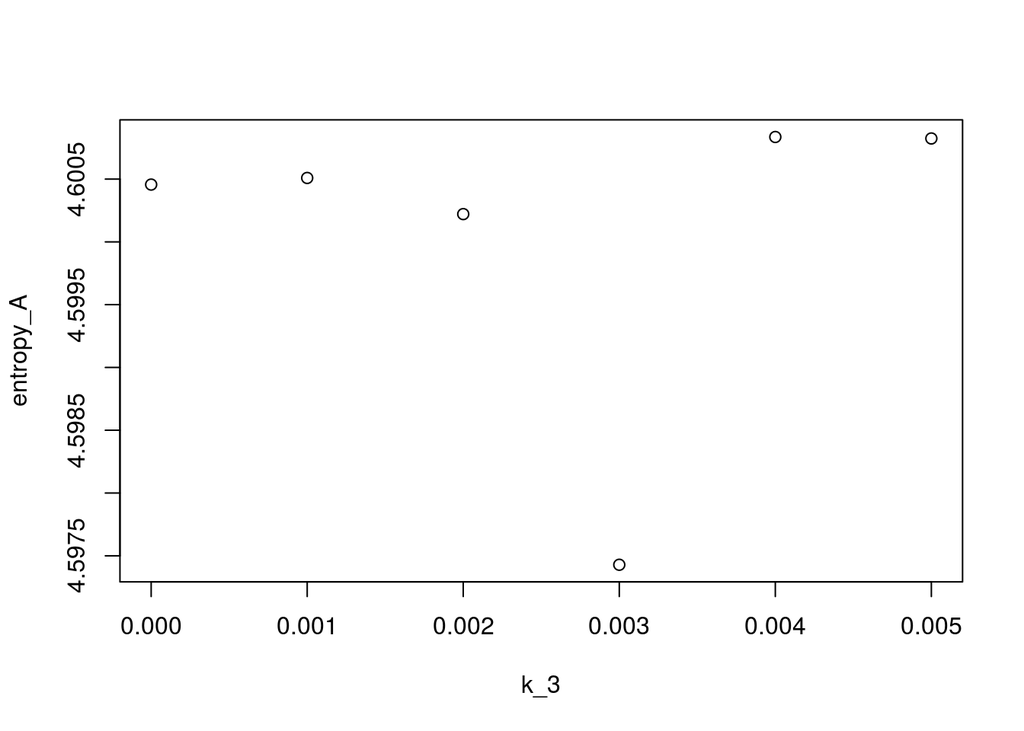

```r
numberofrealisations = 100;
entropy_A <- rep(0,6);
count1 = 0;
for (k_3 in seq(0,0.005,by=0.001)){
  count1 = count1 + 1;
  A_end <- rep(0, numberofrealisations);
  for (count2 in seq(1,numberofrealisations,by=1)){
  output = simple_positive_feedback(1,0.01,k_3,1000,0.1,1,0);
  temp_A = output[length(output)]; #use final time series value
  A_end[count2] = temp_A;
  }
  entropy_A[count1] = entropy(A_end);
}
k_3 = seq(0,0.005,by=0.001);
plot(k_3,entropy_A);
```

Shannon entropy appears to remain constant, making it useless for positive feedback detection.